# Analyse des milliardaires

Les 4 Mousquetaires

# **Introduction**

## Données

Le [dataset](https://www.kaggle.com/datasets/nelgiriyewithana/billionaires-statistics-dataset/) utilisé par notre groupe contient des données sur les milliardaires à travers le monde contenant 2540 observations et un total de 35 variables.

Ce dataset provient de [Nidula Elgiriyewithana](https://www.linkedin.com/in/nidula/), un ingénieur chercheur en IA et regroupe un ensemble d’informations sur les milliardaires.

La structure du dataset est le suivant :

- Le classement du milliardaire (rank)
- Le montant de sa fortune (finalWorth)
- Le secteur économique dans lequel le milliardaire opère (category, industries)
- Les informations personnelles du milliardaire (personName, age, country, state, city, countryOfCitizenship, gender, birthDate, …)
- L’entreprise à l’origine de leur fortune ou le domaine spécifique à l’origine de la fortune (source)
- Le nom de l’organisme ou entreprise affiliée actuellement à ces milliardaires (organization)
- Un indicateur si le milliardaire a produit ou hérité de sa fortune (selfMade, status)
- L’indice des prix à la consommation (2010 base 100) du pays dans lequel ce milliardaire vit en 2019 (cpi_country)
- L’inflation des prix en pourcentage entre le début et la fin de l’année 2019 dans lequel ce millionaire vit (cpi_country_change)
- Le PIB du pays dans lequel ce milliardaire vit (gdp_country)
- Des informations sur le taux d’éducation dans le primaire et le supérieur du pays dans lequel ce milliardaire vit (gross_tertiary_education_enrollment, gross_primary_education_enrollment_country)
- L’espérance de vie (life_expectancy_country)
- Le taux de recettes fiscales en pourcentage du PIB (tax_revenue_country_country)
- Le taux d’imposition sur les entreprises en pourcentage des bénéfices commerciaux (total_tax_rate_country)
- La population du pays dans lequel le milliardaire réside (population_country)

Cependant, certaines variables se recoupent. En effet, personName, qui inclut le nom et le prénom, se retrouve dans lastName (nom) et firstName (prénom). La date d’anniversaire entière du milliardaire (birthDate), qui est présente, est divisée aussi dans les données par birthYear, birthMonth et birthDay. Le pays où habite le milliardaire est présent (country), mais, on trouve aussi les coordonnées du pays d’origine du pays (latitude_country,longitude_country). Les variables category et industries sont redondantes.

Ce dataset est composé, pour les variables pertinentes, de données : discrètes, continues et nominale.

Nous avons choisi ce dataset car :

- Il est complet et toutes les informations nécessaires pour répondre à nos questions y figurent.
- Nous avons la volonté et la curiosité d’en apprendre plus sur les milliardaires comme la provenance de leur richesse et leur répartition dans le monde nous intéresse.
- Avec cette large quantitée d’informations variées, il est possible d’obtenir des réponses plus ou moins pertinentes sur des questions qu’on pourrait tous se poser et d’en tirer des conclusions générales d’un point de vue sociologique. (proportions d’hommes/femmes, gagnée par l’héritage ou le travail, etc.)

Notre travail s’articule autour de cette question : Quels facteurs expliquent l’émergence et la concentration des milliardaires?

# **Analyse exploratoire**

## I. Géographie de la richesse mondiale

## Question 1 : Comment se répartit la richesse des billionaires ?

**Question et problème étudié**

On cherche ici à comprendre la structure de la richesse au sein même du club des milliardaires. La question est de savoir si la fortune est répartie de manière “homogène” (la plupart des milliardaires ayant des fortunes similaires) ou si elle est extrêmement concentrée au sommet.

L’hypothèse est une distribution suivant une **loi de puissance** : une immense majorité de “petits” milliardaires (entre 1 et 5 milliards) et une poignée d’individus possédant des fortunes dépassant l’entendement, créant une inégalité flagrante même au sein de l’élite.

**Visualisation**

Pour cette analyse, un **histogramme combiné à une courbe de densité** est idéal. Nous utilisons une **échelle logarithmique** sur l’axe des abscisses.

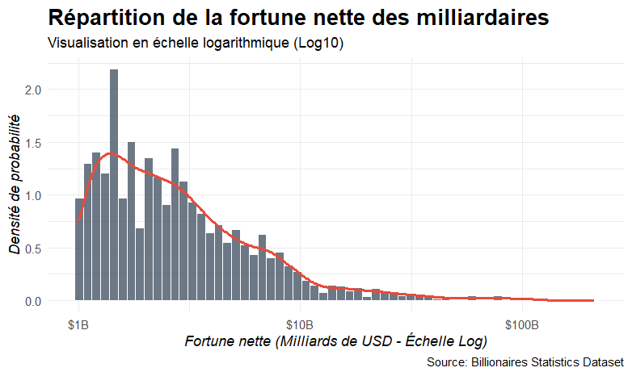

Diagramme de la question 1 (Huy Bui)

**Interprétation et réponse**

L’analyse confirme une asymétrie radicale de la richesse :

La masse des “petits” milliardaires : La plus haute densité (le sommet de la courbe) se situe juste après le seuil de 1 milliard de dollars. C’est là que se trouve le “gros des troupes”.

La “Longue Traîne” (Long Tail) : Plus on avance vers la droite (vers les 10, 50, 100 milliards), plus le nombre de personnes chute drastiquement.

Le club des Centimilliardaires : Les individus comme Bernard Arnault ou Elon Musk sont des “outliers” (données aberrantes statistiquement). Leur richesse est si élevée qu’ils forment une catégorie à part entière, presque déconnectée du reste du classement.

En conclusion, la richesse des milliardaires ne suit pas une courbe en cloche (normale). C’est un système où “le gagnant rafle presque tout”, reflétant les dynamiques de capitalisation boursière où quelques entreprises dominantes propulsent leurs propriétaires vers des sommets isolés.

## Question 2 : Quelle est la répartition des milliardaires dans les différentes industries ?

**Question et problème étudié**

On se demande dans quelles industries on trouve le plus de milliardaires. Est-ce que c’est réparti à peu près équitablement, ou est-ce que quelques secteurs dominent largement ?

On parie plutôt sur la seconde option : la finance, la tech et l’industrie devraient concentrer la majorité des fortunes.

**Visualisation**

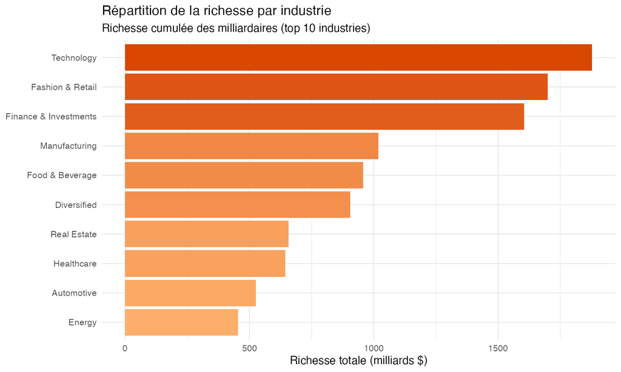

Diagramme de la question 2 (Alexis)

**Interprétation et réponse**

Cela justifie l’essor du numérique, et les tendances économiques qui l’accompagne.

## Question 3 : Quelle est la génération qui regroupe le plus grand nombre de milliardaires ?

**Question et problème étudié**

Avant d’analyser les données, plusieurs hypothèses peuvent être formulées. Les anciennes générations (Génération X et surtout Baby-Boomers) devraient largement dominer le classement, grâce à des conditions favorables d’accumulation du capital, notamment dans des secteurs comme l’immobilier, la finance et l’industrie et à leur position centrale lors de la révolution technologique (Google, Amazon, Apple, Nvidia).

À l’inverse, les Millennials devraient rester minoritaires en raison de leur âge, tandis que la Génération Z serait quasi absente. Les générations plus anciennes, enfin, verraient leur présence réduite par des facteurs démographiques.

**Visualisation**

Un diagramme en barres verticales présente le nombre et le pourcentage de milliardaires par génération, de la plus ancienne à la plus récente, afin de comparer clairement leur poids relatif.

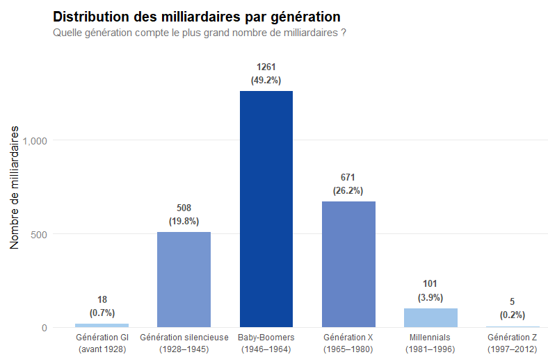

**Interprétation et réponse**

Les données confirment clairement nos hypothèses. Les Baby-Boomers sont la génération la plus représentée (49,2 %), et, avec la Génération X (26,2 %), concentrent plus de 75 % des milliardaires. Cette domination s’explique par leur position favorable dans le temps, leur ayant permis d’accumuler du capital et de profiter pleinement des grandes phases de création de richesse.

La Génération silencieuse reste significative (19,8 %), principalement grâce à des patrimoines issus du capitalisme industriel et souvent transmis ou conservés sur le long terme.

À l’opposé, les Millennials restent marginaux (3,9 %), tandis que la Génération Z est presque inexistante dans l’échantillon (0,2 %).

## Question 4 : Où sont répartis les milliardaires dans le monde ?

**Question et problème étudié**

On cherche à comprendre la répartition géographique des milliardaires afin de voir si elle est concentrée dans certains pays ou régions du monde. On s’attend à ce que les milliardaires soient fortement concentrés dans les pays les plus riches et économiquement développés, notamment les États-Unis, la Chine, l’Allemagne, la France et le Royaume-Uni. Ces pays offrent des écosystèmes favorables à la création de richesse, avec des marchés financiers matures, des infrastructures solides et des opportunités d’affaires.

**Visualisation**

Pour cette analyse, il est pertinent d’utiliser une carte du monde avec des cercles proportionnels à la concentration de milliardaires dans chaque ville. Cela permet de visualiser rapidement les zones de forte concentration et de comparer les pays entre eux.

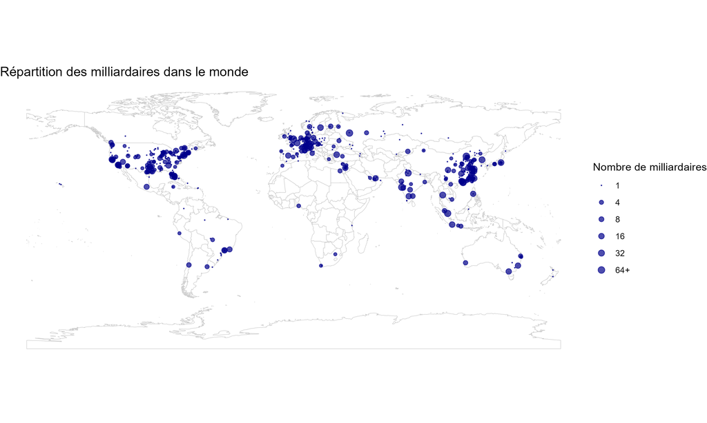

**Interprétation et réponse**

Les données confirment globalement nos hypothèses. En majorité, on retrouve les milliardaires dans les pays les plus riches et économiquement développés, que ce soit aux États-Unis, en Chine et en Europe de l’Ouest. Cependant, on observe aussi des concentrations significatives dans des pays émergents comme l’Inde, qui a vu une croissance économique rapide ces dernières années, créant ainsi de nouvelles opportunités pour la création de richesse.

## Question 5 : Comment se répartissent les milliardaires dans les états américains ?

**Question et problème étudié**

Les États-Unis sont un grand pays qui concentrent des milliardaires. Cependant, la répartition de la population dans ce pays est inégale donc on suppose que les milliardaires se concentrent dans les grandes villes qui sont dans les états qui concentrent la population (Californie, New York, …). Les états ruraux comptent pas ou peu de milliardaires en comparaison (Wyoming, …). L’objectif de cette data visualisation est de vérifier cette hypothèse.

**Visualisation**

On a choisi de représenter cela avec une carte pour rendre cela visuel, pour avoir l’information qui accroche le regard. Par ailleurs, représenter cela avec un diagramme à barre, qui convient tout à fait, nous aurait fait perdre de la données car représenter 42 données en abscisse prend de la place. La carte est mieux pour représenter l’ensemble de données.

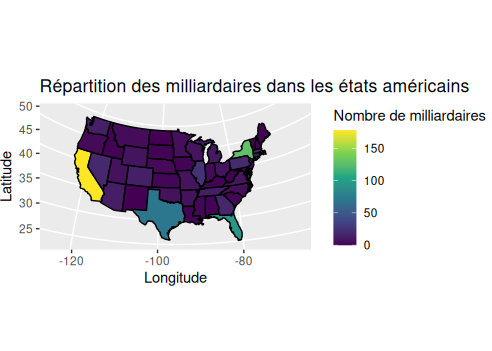

Diagramme de la question 5 (Emma)

**Interprétation et réponse**

Les états les plus peuplés concentrent le plus de milliardaires : Californie, Texas, Floride et New York. Ce sont les états qui concentrent des villes importantes : Los Angeles, New York, Austin, Dallas, Miami, … D’autant plus que la Silicon Valley, épicentre des entreprises de la tech américains, se trouvent en Californie, ce qui explique qu’elle compte plus de 150 milliardaires. Sans surprise, les autres états comptent entre 0 et 50 milliardaires. La visualisation répond à la question.